# F9_03_PROG_CODE

Activity code · Number report

## Overview

**Description**

Activity2 - Activity code

**Table**

`F9-P03-T00-PROGRAM-TWO` (one)

**Location code**

`F990-PC-PART-03-LINE-04-ABCD`

**Family**

`F990-PC-PART-03-LINE-04-ABCD` · siblings: F9_03_PROG_DESC, F9_03_PROG_EXP, F9_03_PROG_GRANT, F9_03_PROG_REV, F9_03_PROG_EXP_OTH_TOT, F9_03_PROG_GRANT_OTH_TOT

**Data type**

numeric (xsd: IntegerNNType, )

**Scope**

PC

**Status**

unreviewed

12

xpaths mapped (7 observed)

10,093

filings with a value

2009–2024

tax years observed

11

open flags (1 errors)

## Flags

[output not shown]

## Xpaths

All mapped xpaths (under /Return/ReturnData or /Return/ReturnHeader), oldest first. Charts label each series by its xpath.

| Xpath | Form | Chart label | First year | Last year | Versions | Filings | Repeats in |
| --- | --- | --- | --- | --- | --- | --- | --- |
| IRS990/ActivityCode | 990 | same | 2009 | 2012 | 15 | 1,046 | 0.0% |
| IRS990/Activity2/ActivityCode | 990 | same | 2009 | 2012 | 14 | 395 | 0.0% |
| IRS990/Activity3/ActivityCode | 990 | same | 2009 | 2012 | 14 | 282 | 0.0% |
| IRS990/ActivityCd | 990 | same | 2013 | 2024 | 31 | 5,327 | 0.0% |
| IRS990/ProgSrvcAccomActy2Grp/ActivityCd | 990 | same | 2013 | 2024 | 31 | 1,727 | 0.0% |
| IRS990/ProgSrvcAccomActy3Grp/ActivityCd | 990 | same | 2013 | 2024 | 30 | 1,119 | 0.0% |
| IRS990/ProgSrvcAccomActyOtherGrp/ActivityCd | 990 | same | 2013 | 2024 | 24 | 197 | 25.9% |
| IRS990/ActivityOther/ActivityCode | 990 | Other |  |  |  | 0 |  |
| IRS990/Form990PartIII/Activity2/ActivityCode | 990 | Other |  |  |  | 0 |  |
| IRS990/Form990PartIII/Activity3/ActivityCode | 990 | Other |  |  |  | 0 |  |
| IRS990/Form990PartIII/ActivityCode | 990 | Other |  |  |  | 0 |  |
| IRS990/Form990PartIII/ActivityOther/ActivityCode | 990 | Other |  |  |  | 0 |  |

## Coverage

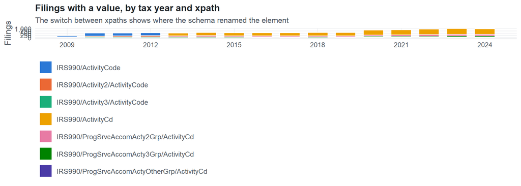

**Table view**

Table view: filings by tax year and series

| Tax year | IRS990/ActivityCode | IRS990/Activity2/ActivityCode | IRS990/Activity3/ActivityCode | IRS990/ActivityCd | IRS990/ProgSrvcAccomActy2Grp/ActivityCd | IRS990/ProgSrvcAccomActy3Grp/ActivityCd | IRS990/ProgSrvcAccomActyOtherGrp/ActivityCd |
| --- | --- | --- | --- | --- | --- | --- | --- |
| 2009 | 102 | 46 | 38 | 0 | 0 | 0 | 0 |
| 2010 | 320 | 106 | 68 | 0 | 0 | 0 | 0 |
| 2011 | 308 | 117 | 81 | 0 | 0 | 0 | 0 |
| 2012 | 316 | 126 | 95 | 0 | 0 | 0 | 0 |
| 2013 | 0 | 0 | 0 | 309 | 120 | 81 | 1 |
| 2014 | 0 | 0 | 0 | 343 | 125 | 85 | 8 |
| 2015 | 0 | 0 | 0 | 340 | 114 | 68 | 7 |
| 2016 | 0 | 0 | 0 | 334 | 113 | 75 | 12 |
| 2017 | 0 | 0 | 0 | 340 | 110 | 67 | 11 |
| 2018 | 0 | 0 | 0 | 343 | 115 | 77 | 9 |
| 2019 | 0 | 0 | 0 | 362 | 109 | 70 | 18 |
| 2020 | 0 | 0 | 0 | 534 | 164 | 99 | 28 |
| 2021 | 0 | 0 | 0 | 555 | 169 | 106 | 30 |
| 2022 | 0 | 0 | 0 | 608 | 183 | 120 | 25 |
| 2023 | 0 | 0 | 0 | 624 | 204 | 135 | 29 |
| 2024 | 0 | 0 | 0 | 635 | 201 | 136 | 19 |

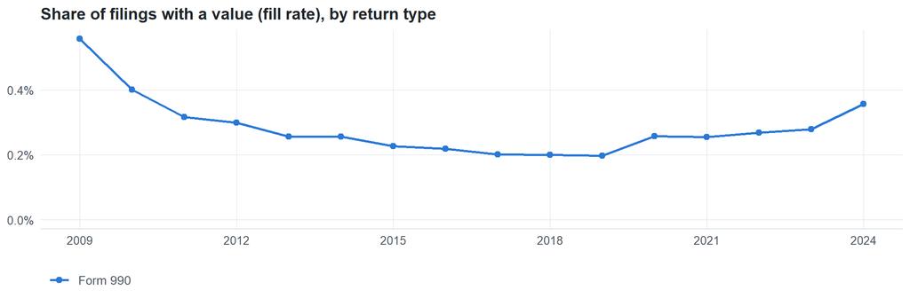

**Table view**

Table view: fill rate

| Tax year | Return type | Filings | All filings | Fill rate |
| --- | --- | --- | --- | --- |
| 2009 | Form 990 | 186 | 33,311 | 0.56% |
| 2010 | Form 990 | 494 | 123,025 | 0.40% |
| 2011 | Form 990 | 506 | 159,504 | 0.32% |
| 2012 | Form 990 | 537 | 179,688 | 0.30% |
| 2013 | Form 990 | 511 | 198,855 | 0.26% |
| 2014 | Form 990 | 561 | 218,619 | 0.26% |
| 2015 | Form 990 | 529 | 233,519 | 0.23% |
| 2016 | Form 990 | 534 | 243,903 | 0.22% |
| 2017 | Form 990 | 528 | 261,612 | 0.20% |
| 2018 | Form 990 | 544 | 271,442 | 0.20% |
| 2019 | Form 990 | 559 | 283,694 | 0.20% |
| 2020 | Form 990 | 825 | 320,342 | 0.26% |
| 2021 | Form 990 | 859 | 336,480 | 0.26% |
| 2022 | Form 990 | 936 | 349,055 | 0.27% |
| 2023 | Form 990 | 992 | 354,768 | 0.28% |
| 2024 | Form 990 | 988 | 277,298 | 0.36% |

## Repeating groups

Table cardinality in the concordance: **one**. 1 of 7 observed xpaths repeat within a filing.

Repeating element each xpath was observed in (from the raw indexed xpath)

| Xpath | Repeating element | Filings (summed over years) |
| --- | --- | --- |
| IRS990/Activity2/ActivityCode | (none) | 395 |
| IRS990/Activity3/ActivityCode | (none) | 282 |
| IRS990/ActivityCode | (none) | 1046 |
| IRS990/ActivityCd | (none) | 5327 |
| IRS990/ProgSrvcAccomActy2Grp/ActivityCd | (none) | 1727 |
| IRS990/ProgSrvcAccomActy3Grp/ActivityCd | (none) | 1119 |
| IRS990/ProgSrvcAccomActyOtherGrp/ActivityCd | (none) | 131 |
| IRS990/ProgSrvcAccomActyOtherGrp/ActivityCd | IRS990/ProgSrvcAccomActyOtherGrp | 66 |

## Values

| Result | Check | Detail |
| --- | --- | --- |
| ✓ pass | Values parse as numbers | 100.0% of values are numeric |
| ⚠ fail | Pooled xpaths are on the same scale (same return type) | medians differ 116505.7x (990: IRS990/Activity3/ActivityCode vs IRS990/ProgSrvcAccomActyOtherGrp/ActivityCd) |
| ✓ pass | One scale across xpaths (fraction vs percent) | IRS990/Activity2/ActivityCode: large count or amount; IRS990/Activity3/ActivityCode: large count or amount; IRS990/ActivityCd: large count or amount; IRS990/ActivityCode: large count or amount; IRS990… |

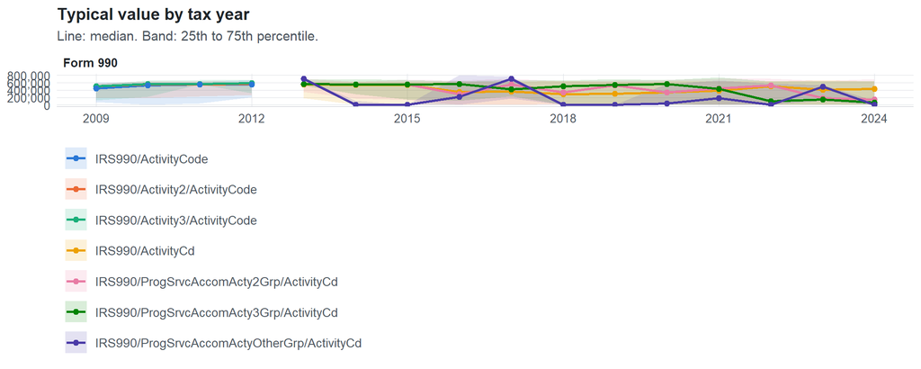

**Table view**

Table view: quartiles by tax year

| Series | Return | Tax year | Filings | P25 | Median | P75 |
| --- | --- | --- | --- | --- | --- | --- |
| IRS990/ActivityCode | 990 | 2009 | 102 | 73,964 | 449,500 | 601,394 |
| IRS990/ActivityCode | 990 | 2010 | 320 | 269.75 | 532,777 | 617,209 |
| IRS990/ActivityCode | 990 | 2011 | 308 | 43,520 | 554,050 | 624,053 |
| IRS990/ActivityCode | 990 | 2012 | 316 | 207,179 | 550,229 | 674,953 |
| IRS990/Activity2/ActivityCode | 990 | 2009 | 46 | 179,603 | 505,769 | 579,914 |
| IRS990/Activity2/ActivityCode | 990 | 2010 | 106 | 187,790 | 555,928 | 640,268 |
| IRS990/Activity2/ActivityCode | 990 | 2011 | 117 | 230,374 | 556,999 | 643,236 |
| IRS990/Activity2/ActivityCode | 990 | 2012 | 126 | 268,217 | 570,037 | 623,230 |
| IRS990/Activity3/ActivityCode | 990 | 2009 | 38 | 120,163 | 506,229 | 556,877 |
| IRS990/Activity3/ActivityCode | 990 | 2010 | 68 | 220,134 | 561,315 | 657,221 |
| IRS990/Activity3/ActivityCode | 990 | 2011 | 81 | 548,487 | 565,701 | 674,934 |
| IRS990/Activity3/ActivityCode | 990 | 2012 | 95 | 317,983 | 583,711 | 672,360 |
| IRS990/ActivityCd | 990 | 2013 | 309 | 182,211 | 554,752 | 624,403 |
| IRS990/ActivityCd | 990 | 2014 | 343 | 501 | 543,258 | 623,583 |
| IRS990/ActivityCd | 990 | 2015 | 340 | 125.11 | 545,227 | 623,541 |
| IRS990/ActivityCd | 990 | 2016 | 334 | 5.67 | 350,647 | 623,771 |
| IRS990/ActivityCd | 990 | 2017 | 340 | 296.09 | 357,784 | 620,027 |
| IRS990/ActivityCd | 990 | 2018 | 343 | 26,354 | 284,696 | 649,433 |
| IRS990/ActivityCd | 990 | 2019 | 362 | 220.04 | 303,996 | 621,294 |
| IRS990/ActivityCd | 990 | 2020 | 534 | 241.74 | 335,486 | 638,580 |
| IRS990/ActivityCd | 990 | 2021 | 554 | 275.37 | 383,592 | 644,205 |
| IRS990/ActivityCd | 990 | 2022 | 608 | 123.64 | 509,560 | 631,827 |
| IRS990/ActivityCd | 990 | 2023 | 624 | 66.70 | 414,823 | 673,328 |
| IRS990/ActivityCd | 990 | 2024 | 634 | 48.44 | 428,712 | 640,783 |
| IRS990/ProgSrvcAccomActy2Grp/ActivityCd | 990 | 2013 | 120 | 345,101 | 568,504 | 711,172 |
| IRS990/ProgSrvcAccomActy2Grp/ActivityCd | 990 | 2014 | 125 | 173,166 | 551,274 | 624,156 |
| IRS990/ProgSrvcAccomActy2Grp/ActivityCd | 990 | 2015 | 114 | 130,502 | 555,082 | 689,797 |
| IRS990/ProgSrvcAccomActy2Grp/ActivityCd | 990 | 2016 | 113 | 2 | 292,370 | 658,750 |
| IRS990/ProgSrvcAccomActy2Grp/ActivityCd | 990 | 2017 | 110 | 304.60 | 556,895 | 704,673 |
| IRS990/ProgSrvcAccomActy2Grp/ActivityCd | 990 | 2018 | 115 | 227.63 | 332,442 | 638,567 |
| IRS990/ProgSrvcAccomActy2Grp/ActivityCd | 990 | 2019 | 109 | 221.74 | 529,564 | 666,756 |
| IRS990/ProgSrvcAccomActy2Grp/ActivityCd | 990 | 2020 | 164 | 26,769 | 336,120 | 668,570 |
| IRS990/ProgSrvcAccomActy2Grp/ActivityCd | 990 | 2021 | 169 | 3,641 | 447,414 | 711,982 |
| IRS990/ProgSrvcAccomActy2Grp/ActivityCd | 990 | 2022 | 183 | 8,119 | 528,351 | 714,272 |
| IRS990/ProgSrvcAccomActy2Grp/ActivityCd | 990 | 2023 | 204 | 28.64 | 182,913 | 647,310 |
| IRS990/ProgSrvcAccomActy2Grp/ActivityCd | 990 | 2024 | 200 | 2 | 146,465 | 695,498 |
| IRS990/ProgSrvcAccomActy3Grp/ActivityCd | 990 | 2013 | 81 | 521,279 | 562,543 | 688,462 |
| IRS990/ProgSrvcAccomActy3Grp/ActivityCd | 990 | 2014 | 85 | 293,710 | 557,505 | 691,779 |
| IRS990/ProgSrvcAccomActy3Grp/ActivityCd | 990 | 2015 | 68 | 145,917 | 552,552 | 673,051 |
| IRS990/ProgSrvcAccomActy3Grp/ActivityCd | 990 | 2016 | 75 | 106,612 | 567,067 | 640,750 |
| IRS990/ProgSrvcAccomActy3Grp/ActivityCd | 990 | 2017 | 67 | 228,516 | 425,295 | 669,896 |
| IRS990/ProgSrvcAccomActy3Grp/ActivityCd | 990 | 2018 | 77 | 229.36 | 500,302 | 664,601 |
| IRS990/ProgSrvcAccomActy3Grp/ActivityCd | 990 | 2019 | 70 | 99.04 | 541,811 | 694,552 |
| IRS990/ProgSrvcAccomActy3Grp/ActivityCd | 990 | 2020 | 99 | 264.58 | 571,214 | 671,317 |
| IRS990/ProgSrvcAccomActy3Grp/ActivityCd | 990 | 2021 | 106 | 922.54 | 428,049 | 741,479 |
| IRS990/ProgSrvcAccomActy3Grp/ActivityCd | 990 | 2022 | 120 | 3,762 | 96,104 | 639,538 |
| IRS990/ProgSrvcAccomActy3Grp/ActivityCd | 990 | 2023 | 135 | 31.61 | 144,570 | 634,302 |
| IRS990/ProgSrvcAccomActy3Grp/ActivityCd | 990 | 2024 | 135 | 3 | 63,828 | 654,543 |
| IRS990/ProgSrvcAccomActyOtherGrp/ActivityCd | 990 | 2013 | 1 | 711,190 | 711,190 | 711,190 |
| IRS990/ProgSrvcAccomActyOtherGrp/ActivityCd | 990 | 2014 | 8 | 94.56 | 188.50 | 114,790 |
| IRS990/ProgSrvcAccomActyOtherGrp/ActivityCd | 990 | 2015 | 7 | 1 | 1 | 3 |
| IRS990/ProgSrvcAccomActyOtherGrp/ActivityCd | 990 | 2016 | 12 | 2.50 | 221,000 | 805,655 |
| IRS990/ProgSrvcAccomActyOtherGrp/ActivityCd | 990 | 2017 | 11 | 169,476 | 711,273 | 766,700 |
| IRS990/ProgSrvcAccomActyOtherGrp/ActivityCd | 990 | 2018 | 9 | 3.75 | 4 | 6.25 |
| IRS990/ProgSrvcAccomActyOtherGrp/ActivityCd | 990 | 2019 | 18 | 1.50 | 5.11 | 391.28 |
| IRS990/ProgSrvcAccomActyOtherGrp/ActivityCd | 990 | 2020 | 28 | 4 | 35,399 | 562,229 |
| IRS990/ProgSrvcAccomActyOtherGrp/ActivityCd | 990 | 2021 | 30 | 2.95 | 183,484 | 660,788 |
| IRS990/ProgSrvcAccomActyOtherGrp/ActivityCd | 990 | 2022 | 25 | 4.92 | 235.38 | 574,195 |
| IRS990/ProgSrvcAccomActyOtherGrp/ActivityCd | 990 | 2023 | 29 | 115,115 | 491,585 | 539,722 |
| IRS990/ProgSrvcAccomActyOtherGrp/ActivityCd | 990 | 2024 | 19 | 3.16 | 4.47 | 107,735 |

Summary by xpath and return type (all years)

| Series | Return | Filings | % numeric | % zero | % negative | Median (typical year) | P99 (typical year) |
| --- | --- | --- | --- | --- | --- | --- | --- |
| IRS990/ActivityCode | 990 | 1,046 | 100 | 1.53 | 0 | 531390 | 900099 |
| IRS990/Activity2/ActivityCode | 990 | 395 | 100 | 0.51 | 0 | 551950 | 900099 |
| IRS990/Activity3/ActivityCode | 990 | 282 | 100 | 1.06 | 0 | 599152 | 894964 |
| IRS990/ActivityCd |  | 2 |  |  |  |  |  |
| IRS990/ActivityCd | 990 | 5,325 | 100 | 6.10 | 0 | 512100 | 900099 |
| IRS990/ProgSrvcAccomActy2Grp/ActivityCd |  | 1 |  |  |  |  |  |
| IRS990/ProgSrvcAccomActy2Grp/ActivityCd | 990 | 1,726 | 100 | 4.44 | 0 | 531210 | 900099 |
| IRS990/ProgSrvcAccomActy3Grp/ActivityCd |  | 1 |  |  |  |  |  |
| IRS990/ProgSrvcAccomActy3Grp/ActivityCd | 990 | 1,118 | 100 | 5.48 | 0 | 528765 | 900099 |
| IRS990/ProgSrvcAccomActyOtherGrp/ActivityCd | 990 | 197 | 100 | 7.66 | 0 | 5 | 900099 |

Scale of each xpath

| Series | P99 (typical year) | Implied scale |
| --- | --- | --- |
| IRS990/Activity2/ActivityCode | 900099 | large count or amount |
| IRS990/Activity3/ActivityCode | 894964 | large count or amount |
| IRS990/ActivityCd | 900099 | large count or amount |
| IRS990/ActivityCode | 900099 | large count or amount |
| IRS990/ProgSrvcAccomActy2Grp/ActivityCd | 900099 | large count or amount |
| IRS990/ProgSrvcAccomActy3Grp/ActivityCd | 900099 | large count or amount |
| IRS990/ProgSrvcAccomActyOtherGrp/ActivityCd | 900099 | large count or amount |

## Examples

| Tax year | Return | Xpath | Organization | Value | Source |
| --- | --- | --- | --- | --- | --- |
| 2024 | 990 | IRS990/ActivityCd | Therapy Plus | 30 | [XML](https://gt990datalake-rawdata.s3.amazonaws.com/EfileData/XmlFiles/202513019349301551_public.xml) |
| 2024 | 990 | IRS990/ProgSrvcAccomActy2Grp/ActivityCd | RIO SALADO SPORTSMANS CLUB INC | 0 | [XML](https://gt990datalake-rawdata.s3.amazonaws.com/EfileData/XmlFiles/202610839349300321_public.xml) |
| 2024 | 990 | IRS990/ProgSrvcAccomActy3Grp/ActivityCd | RIO SALADO SPORTSMANS CLUB INC | 0 | [XML](https://gt990datalake-rawdata.s3.amazonaws.com/EfileData/XmlFiles/202610839349300321_public.xml) |
| 2024 | 990 | IRS990/ProgSrvcAccomActyOtherGrp/ActivityCd | Friends For Life Foundation Inc | 900099 | [XML](https://gt990datalake-rawdata.s3.amazonaws.com/EfileData/XmlFiles/202501209349301530_public.xml) |
| 2023 | 990 | IRS990/ActivityCd | DOT NGO CHARITIES INC | 99 | [XML](https://gt990datalake-rawdata.s3.amazonaws.com/EfileData/XmlFiles/202403209349327785_public.xml) |
| 2023 | 990 | IRS990/ProgSrvcAccomActy2Grp/ActivityCd | CALDWELL COUNTY COMMUNITY SERVICES FOUNDATION | 81321 | [XML](https://gt990datalake-rawdata.s3.amazonaws.com/EfileData/XmlFiles/202403579349300050_public.xml) |
| 2023 | 990 | IRS990/ProgSrvcAccomActy3Grp/ActivityCd | ST JAMES FOUNDATION | 501 | [XML](https://gt990datalake-rawdata.s3.amazonaws.com/EfileData/XmlFiles/202423169349302697_public.xml) |
| 2023 | 990 | IRS990/ProgSrvcAccomActyOtherGrp/ActivityCd | SCOTT COUNTY YOUTH BASEBALL BOOSTERS | 4 | [XML](https://gt990datalake-rawdata.s3.amazonaws.com/EfileData/XmlFiles/202420469349301337_public.xml) |
| 2022 | 990 | IRS990/ActivityCd | East Pasco Meals on Wheels Inc | 1 | [XML](https://gt990datalake-rawdata.s3.amazonaws.com/EfileData/XmlFiles/202333009349301928_public.xml) |
| 2022 | 990 | IRS990/ProgSrvcAccomActy2Grp/ActivityCd | Greater Phoenix Urban | 611600 | [XML](https://gt990datalake-rawdata.s3.amazonaws.com/EfileData/XmlFiles/202411369349314201_public.xml) |
| 2022 | 990 | IRS990/ProgSrvcAccomActy3Grp/ActivityCd | EAST HEIGHTS LODGE NO 2241 | 900003 | [XML](https://gt990datalake-rawdata.s3.amazonaws.com/EfileData/XmlFiles/202341809349301439_public.xml) |
| 2022 | 990 | IRS990/ProgSrvcAccomActyOtherGrp/ActivityCd | CREOLE INC | 0004 | [XML](https://gt990datalake-rawdata.s3.amazonaws.com/EfileData/XmlFiles/202341039349300944_public.xml) |

## Reviewer checklist

- The definition matches the form line and instructions for every xpath’s schema years.
- Every xpath pooled here measures the same thing on the 990 and 990-EZ (close enough for analysis).
- The coverage chart has no unexplained gaps or jumps between tax years.
- Each open flag is fixed, or accepted with a note in validation_log.csv.
- Counts are whole numbers and plausible (e.g. employees, volunteers, voting members).
- Ratios and percentages use one scale (0-1 or 0-100) across all xpaths and years.
- Units match the form line (hours per week, number of states, percent of support).

Record the review as a row in `inst/extdata/src/validation_log.csv` (variable_name, reviewer, date, status, note). Evidence built 2026-09-23 17:09:04 MST from the ef2 DuckDB builds (tax years 2009–2024).